# test

07 March, 2018

# Main

## Finding priors for the beta distribution

Beta distribution is the natural prior for a binomial/bernoulli distribution. Considering distribution of a binomial variable $X\gvn\theta\sim Binom(\theta)$, in order to make its marginalisd distribution $P(X) = \int P(X\gvn\theta)P(\theta).d\theta$ analytically tractable, one of the choice is to assume $\theta\sim Beta(M,\alpha)$, so that:

$$\begin{aligned}
P(\theta) &=\frac{x^{\alpha - 1}(1-x)^{M-\alpha-1}}{B(\alpha,M-\alpha)}
\\
E(\theta) &={\alpha\over M }
\end{aligned}$$

### Constraint 1:

$$\begin{aligned}
P(\theta\le 0.25) = P(\theta\ge 0.75) = 0.05 \\
P(\theta\le 0.75)=0.95
\end{aligned}$$

### Constraint 2

$$\begin{aligned}
\text{argmax}_\theta(P(\theta))=0.4 \\
P(\theta\le 0.3) = 0.1
\end{aligned}$$

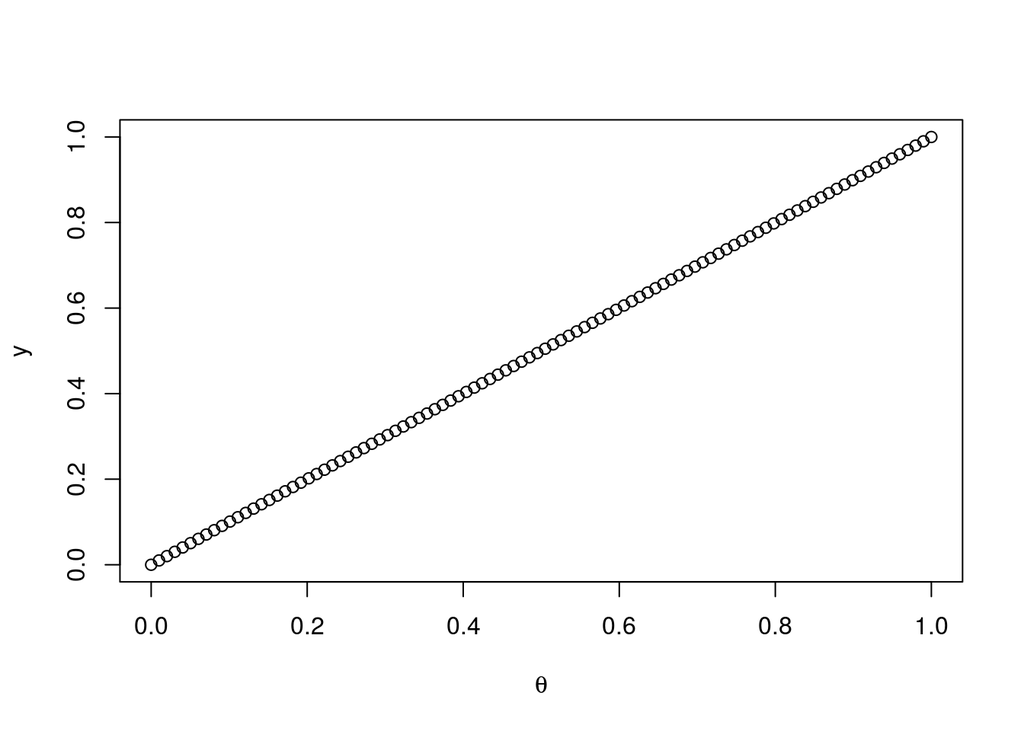

```
## [1] 1.10134e-09
## [1] 0.1
## y_pred: 0.4 0.1
## y_true: 0.4 0.1
```

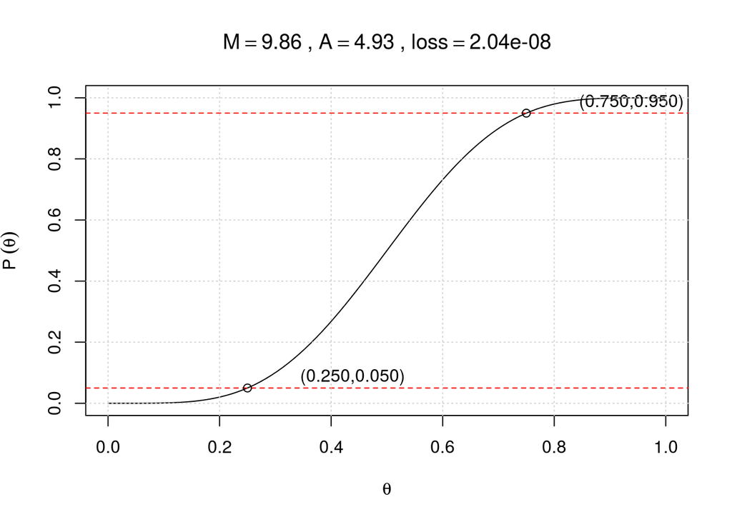

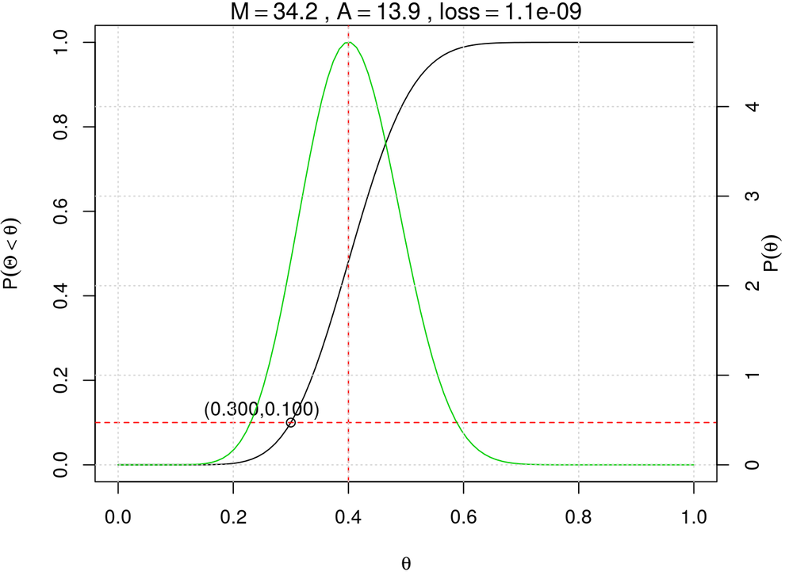

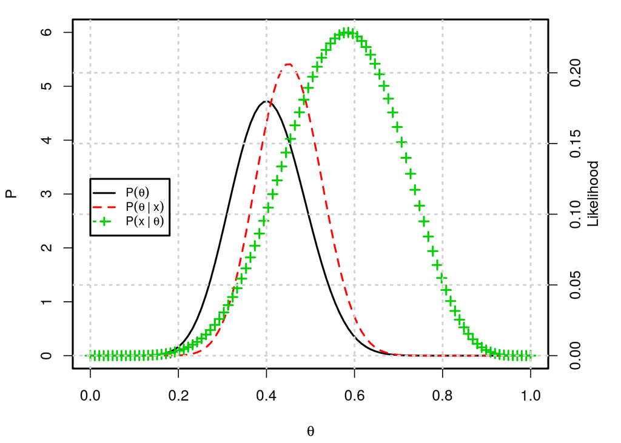

Inference of posterior distribution on parameter $\theta$ given mutatble sequence: 011100101101

[figure not shown]

```
## 0.11 with absolute error < 1.4e-07
```

```
## 0.0769 with absolute error < 8.5e-16
```

```
## 1 with absolute error < 1.1e-07
```

```
## 0.11 with absolute error < 5.3e-10
```

```
## 0.0769 with absolute error < 8.5e-16
```

```
## [1] 1.43
```

### Basics for Bayesian inference

$$\begin{aligned}
\text{likelihood}&: f(\theta) = P(x \gvn \theta) \\
\text{prior}&: f(\theta) = P(\theta) \\
\text{posterior}&: f(\theta) = P(\theta \gvn x) = \frac{ P(x\gvn \theta) P(\theta) }{P(x) } \\
\text{marginal likelihood} &: P(x) = \int P(x\gvn \theta) P(\theta).d\theta
\end{aligned}$$

The observed toss sequence is: 011100101101

## Infer a three variable Bayesian network

$${\frac {\left(n!\right)\Gamma \left(\sum \alpha _{k}\right)}{\Gamma \left(n+\sum \alpha _{k}\right)}}\prod _{k=1}^{K}{\frac {\Gamma (x_{k}+\alpha _{k})}{\left(x_{k}!\right)\Gamma (\alpha _{k})}}$$

## Number of Bayesian networks:

A V-variable network has $V(V-1)/2$ bivariate interaction (edges), each interaction can have 3 possible status (A->B, A<-B, A B). Hence altogether there are $n(V) = 3^{V(V-1)/2}$ possible networks. For $V=3$,$n(3)=27$

```
## All packages requirements are met: "dagitty","pcalg","jpeg"
```

```
## Loading objects:
##   dat1
## Loading objects:
##   dat2
## [1] -4.29
## [1] -21.1
```

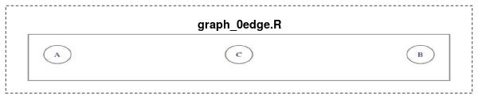

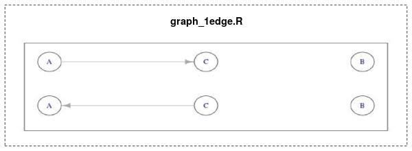

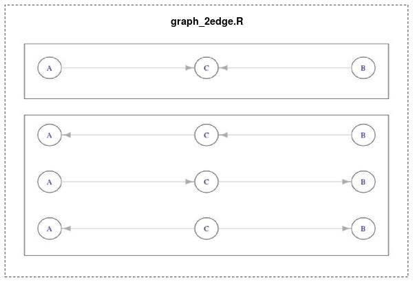

### Comment on the likelihood-equivalent prior

The likelihood-equivalent prior is set so that the imaginary sample size decreases as data is stratified by more variables. For example, if $P(A=1) \sim Beta(\eta(A_0),\eta(A_1))$, then the imaginary sample size for (A=1) is $\eta(A_1)=2$. Hence if we then ask for $P(B=1\gvn A=1)\sim Beta(\eta(B_0A_1),\eta(B_1A_1))$, the prior must then be set so that the total imagnary sample size corresponds to that for A=1 ($\eta(B_0A_1)+\eta(B_1A_1)=\eta(A_1)=2$). Assuming equally probability gives $\eta(B_0A_1)=\eta(B_1A_1)=1$. For 3 variable, we can deduce $8\eta(ABC)=4\eta(AB)=2\eta(A)=\eta(0)$, setting $\eta(ABC)=1$ gives $\eta(ABC)=1,\eta(AB)=2,\eta(A)=4,\eta(0)=8$, corresponding to different levels of stratification.

### Decomposing likelihood function with Dirichlet-multinomial, link it back to beta-binomial

### Effect of imaginary sample size

Setting $\eta(A)=1$ implies

$\eta(ABC)=0.25,\eta(AB)=0.5,\eta(A)=1,\eta(0)=2$

### Evaluate the networks

1. How does the imaginary sample size affects the likelihood?

Because the model prescribed node B to be independent from node A, its prior takes the form:

$P(B=1\gvn A=1)=P(B=1)=\theta \sim Beta(4,4)$ if $\eta(A)=4\eta(ABC)=4$

(**TBC**)

| model | myalgo.bde | bnlearn.bde | bnlearn.bic | iss |
| --- | --- | --- | --- | --- |
| [A][B][C] | -195.70 | -195.70 | -197.41 | 8 |
| [A][B][C\|A] | -180.32 | -180.32 | -181.02 | 8 |
| [B][C][A\|C] | -180.32 | -180.32 | -181.02 | 8 |
| [B][C\|B][A\|C] | -178.58 | -178.58 | -179.99 | 8 |
| [A][C\|A][B\|C] | -178.58 | -178.58 | -179.99 | 8 |
| [C][A\|C][B\|C] | -178.58 | -178.58 | -179.99 | 8 |
| [A][B][C\|A:B] | -180.57 | -180.57 | -183.10 | 8 |

### R Packages

list “deal.bde” “bnlearn.bed” “myalgo.bde”

1. bnlearn also models scores network with AIC, BIC. BIC has the property of non-parametric and does not requires setting the imaginary sample size. comment on pc.stable

### DREAM5